# Math 327 - Homework #1

David Oniani

September 2, 2019

## One-sample t-test

Adapted from: Wm. Bolstad, p. 230 (2012).

You are the statistician responsible for quality standards at a cheese factory. You want to determine whether the mean weight of 20 randomly chosen blocks of cheese labelled “1 kg” is close to 1 kg. The weights (in grams) of the 20 blocks of cheese are:

994, 997, 999, 1003, 994, 998, 1001, 998, 996, 1002,

1004, 995, 994, 995, 998, 1001, 995, 1006, 997, 998

Test whether the mean weight is equal to 1000 grams or not and estimate the mean weight with a 95% confidence interval. Provide interpretations of the results.

```r
# Define a variable to contain the list of cheese block weights
cheese.wgts = c(994, 997, 999, 1003, 994, 998, 1001, 998, 996, 1002, 1004, 995, 994, 995, 998, 1001, 995, 1006, 997, 998)
# Visualate the weights (always plot your data!)
hist (cheese.wgts)
# calculate the t-test results. The t.test function also produces a confidence interval
t.test (cheese.wgts, mu=1000)
```

```
##
##  One Sample t-test
##
## data:  cheese.wgts
## t = -2.2032, df = 19, p-value = 0.04012
## alternative hypothesis: true mean is not equal to 1000
## 95 percent confidence interval:
##  996.5875 999.9125
## sample estimates:
## mean of x
##    998.25
```

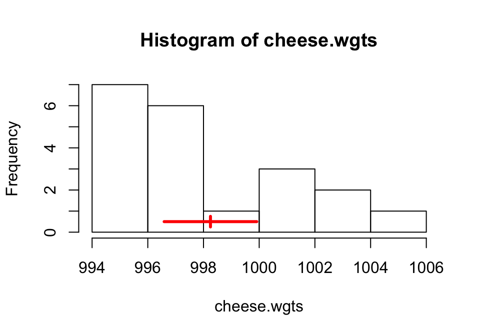

```r
# plot the confidence interval on the histogram
ch.mean = mean (cheese.wgts)
ttest1 = t.test (cheese.wgts, mu=1000)
lines (ttest1$conf.int[1:2], c(0.5, 0.5), col='red', lwd=3)
lines (c(ch.mean, ch.mean), c(0.25, 0.75), col='red', lwd=3)
```

The mean weight in the 20 samples was 998.25 grams, which is statistically significantly below the target value of 1000 grams, p=0.04. The mean weight is between 996.59 grams and 999.91 grams with 95% confidence.

## Two-sample t-test

Adapted from: Wm. Bolstad, p. 273 (2012).

A consumer testing organization obtained samples of size 12 from two brands of emergency flares and measured the burning times in minutes:

Is there a significant difference in mean burning time between the two brands?

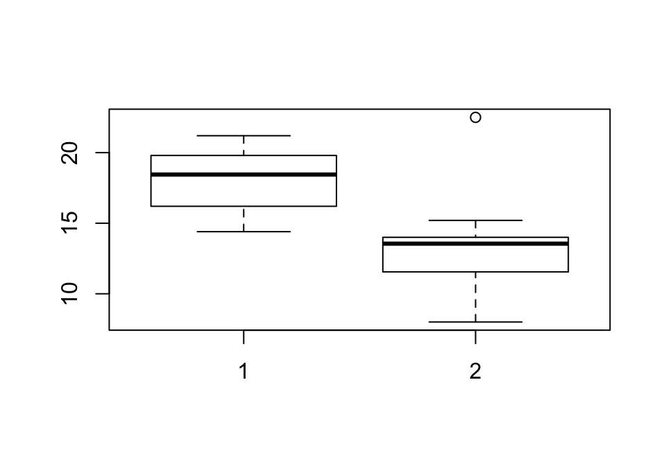

```r
# Define a variable for each group
times.A = c(17.5, 21.2, 20.3, 14.4, 15.2, 19.3, 21.2, 19.1, 18.1, 14.6, 17.2, 18.8)
times.B = c(13.4, 9.9, 13.5, 11.3, 22.5, 14.3, 13.6, 15.2, 13.7, 8, 13.6, 11.8)
# visualize the data
boxplot (times.A, times.B)
```

```r
# calculate the t-test and confidence interval
t.test (times.A, times.B, var.equal=T)
```

```
##
##  Two Sample t-test
##
## data:  times.A and times.B
## t = 3.8179, df = 22, p-value = 0.0009394
## alternative hypothesis: true difference in means is not equal to 0
## 95 percent confidence interval:
##  2.135532 7.214468
## sample estimates:
## mean of x mean of y
##    18.075    13.400
```

The mean burning time in the Group A was 4.675 minutes higher than that in Group B, which was significantly different compared to Group B (18.075 mins vs 13.400 mins), p=0.0009. The difference in mean burning times between the groups was between 2.136 minutes and 7.214 minutes with 95% confidence.

# Paired t-test

A group of 10 students took a pre-test at the beginning of their statistics class and a post-test at the end. The data are in percent (%) units:

[output not shown]

Was there a significant improvement in scores between the pre-test and the post-test?

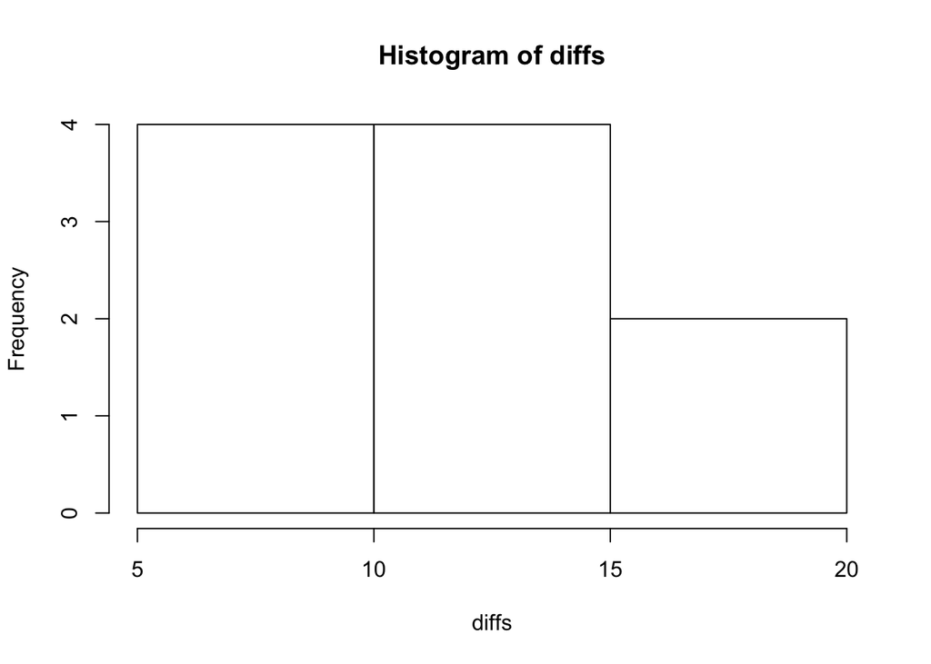

```r
pre.test = c(60, 63, 55, 70, 62, 65, 66, 70, 75, 80)
post.test = c(70, 71, 65, 75, 76, 80, 86, 90, 89, 95)
diffs = post.test - pre.test
hist (diffs)
```

```r
# The paired t-test can be calculated two different ways
t.test (diffs)
```

```
##
##  One Sample t-test
##
## data:  diffs
## t = 8.4776, df = 9, p-value = 1.389e-05
## alternative hypothesis: true mean is not equal to 0
## 95 percent confidence interval:
##   9.604416 16.595584
## sample estimates:
## mean of x
##      13.1
```

```r
t.test (post.test, pre.test, paired = T)
```

```
##
##  Paired t-test
##
## data:  post.test and pre.test
## t = 8.4776, df = 9, p-value = 1.389e-05
## alternative hypothesis: true difference in means is not equal to 0
## 95 percent confidence interval:
##   9.604416 16.595584
## sample estimates:
## mean of the differences
##                    13.1
```

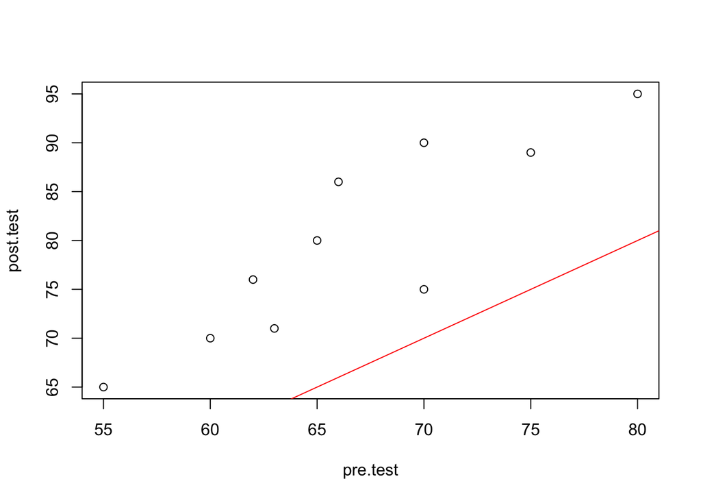

```r
# Scatterplot of post- vs pre-treatment
plot (pre.test, post.test)
# Put a "Y=X" line on the plot - this is the line of "no difference" between pre and post
abline (0, 1,col='red')
```

The mean per-subject increase of 13.100 in scores from pre-test to post-test was statistically significant, p=0.00001. The mean per-subject change in the score was between 9.604 and 16.596 with 95% confidence.